# Hypothesis tests & probability - homework

```r
library(tidyverse)
library(infer)
library(skimr)
data(msleep)
```

1.1 Hypothesis testing - practical

```r
sleep_data <- select(msleep, name, sleep_total)
```

```r
skim(sleep_data)
```

```
── Data Summary ────────────────────────
                           Values
Name                       sleep_data
Number of rows             83
Number of columns          2
_______________________
Column type frequency:
  character                1
  numeric                  1
________________________
Group variables            None

── Variable type: character ────────────────────────────────────────
  skim_variable n_missing complete_rate   min   max empty n_unique
1 name                  0             1     3    30     0       83
  whitespace
1          0

── Variable type: numeric ──────────────────────────────────────────
  skim_variable n_missing complete_rate  mean    sd    p0   p25
1 sleep_total           0             1  10.4  4.45   1.9  7.85
    p50   p75  p100 hist
1  10.1  13.8  19.9 ▅▅▇▆▂
```

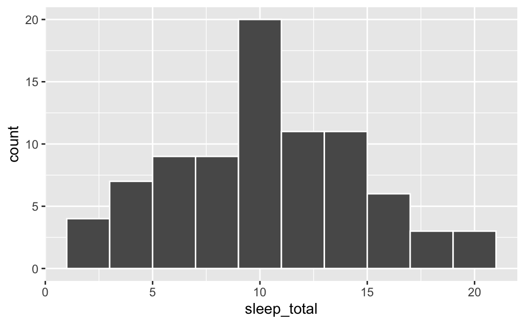

```r
sleep_data %>%
ggplot(aes(x = sleep_total)) +
  geom_histogram(binwidth = 2, color = "white")
```

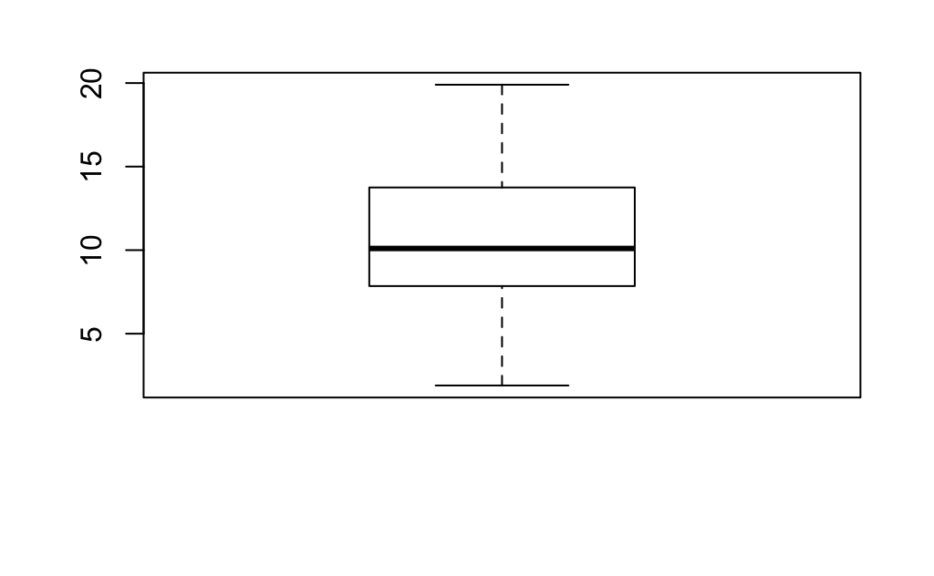

```r
  boxplot(sleep_data$sleep_total)
```

Roughly normal distribution, over 30 samples (83) and independent observations so 1 sample t test is applicable

H0: μsleep_total = 7.0 Hα: μsleep_total ≠ 7.0 α = 0.05

```r
t_stat_infer <- sleep_data %>%
  t_stat(response = sleep_total, mu = 7)

t_stat_infer
```

```
       t
7.029282
```

```r
null_distribution_sleep_total <- sleep_data %>%
  specify(response = sleep_total) %>%
  hypothesize(null = "point", mu = 7) %>%
  calculate(stat = "t")

head(null_distribution_sleep_total)
```

| stat |
| --- |
| 7.029282 |

```
Check to make sure the conditions have been met for the theoretical method. {infer} currently does not check these for you.
```

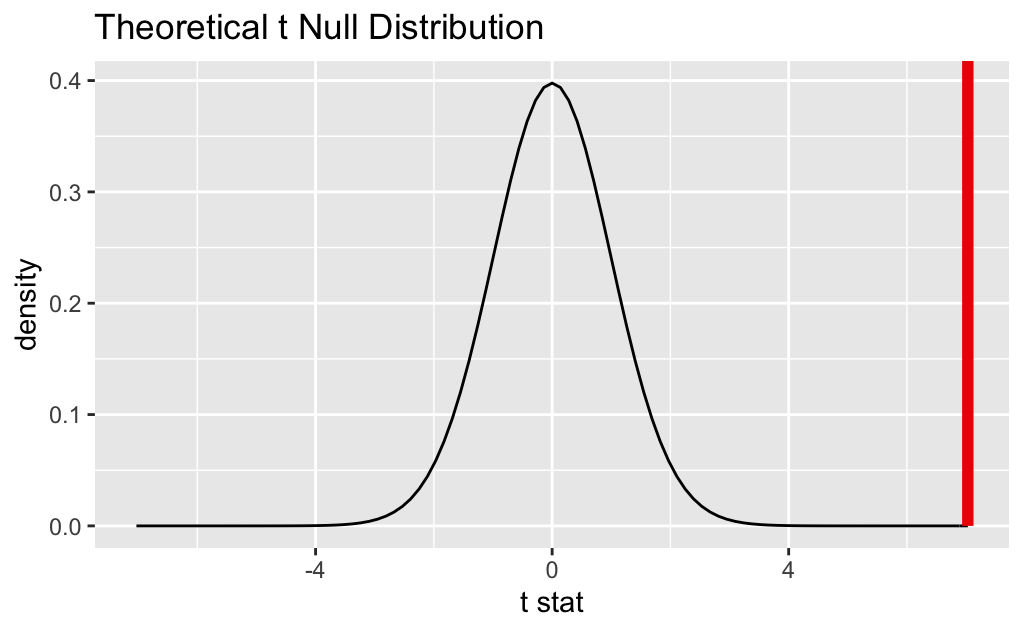

```r
null_distribution_sleep_total %>%
  visualize(method = "theoretical") +
  shade_p_value(obs_stat = t_stat_infer, direction = "both")
```

```r
t_test_results <- sleep_data %>%
  t_test(response = sleep_total, alternative = "two.sided", mu = 7.00)

t_test_results
```

| statistic | t_df | p_value | alternative | lower_ci | upper_ci |
| --- | --- | --- | --- | --- | --- |
| 7.029282 | 82 | 5.628666e-10 | two.sided | 9.461972 | 11.4055 |

p < 0.05 so null hypothesis can be rejected and conclude that jabberwockies sleep significantly different from the overall population mean.

#Perform an appropriate statistical test to determine whether omnivores sleep for significantly longer than herbivores, on average.

```r
msleep %>%
  group_by(vore) %>%
  summarise(n = n())
```

| vore | n |
| --- | --- |
| carni | 19 |
| herbi | 32 |
| insecti | 5 |
| omni | 20 |
| NA | 7 |

```r
vore_sleep <- msleep %>%
  filter(vore == "omni" | vore == "herbi")

vore_sleep
```

| name | genus | vore | order | conservation | sleep_total | sleep_rem | sleep_cycle | awake | brainwt | bodywt |
| --- | --- | --- | --- | --- | --- | --- | --- | --- | --- | --- |
| Owl monkey | Aotus | omni | Primates | NA | 17.0 | 1.8 | NA | 7.0 | 0.01550 | 0.480 |
| Mountain beaver | Aplodontia | herbi | Rodentia | nt | 14.4 | 2.4 | NA | 9.6 | NA | 1.350 |
| Greater short-tailed shrew | Blarina | omni | Soricomorpha | lc | 14.9 | 2.3 | 0.1333333 | 9.1 | 0.00029 | 0.019 |
| Cow | Bos | herbi | Artiodactyla | domesticated | 4.0 | 0.7 | 0.6666667 | 20.0 | 0.42300 | 600.000 |
| Three-toed sloth | Bradypus | herbi | Pilosa | NA | 14.4 | 2.2 | 0.7666667 | 9.6 | NA | 3.850 |
| Roe deer | Capreolus | herbi | Artiodactyla | lc | 3.0 | NA | NA | 21.0 | 0.09820 | 14.800 |
| Goat | Capri | herbi | Artiodactyla | lc | 5.3 | 0.6 | NA | 18.7 | 0.11500 | 33.500 |
| Guinea pig | Cavis | herbi | Rodentia | domesticated | 9.4 | 0.8 | 0.2166667 | 14.6 | 0.00550 | 0.728 |
| Grivet | Cercopithecus | omni | Primates | lc | 10.0 | 0.7 | NA | 14.0 | NA | 4.750 |
| Chinchilla | Chinchilla | herbi | Rodentia | domesticated | 12.5 | 1.5 | 0.1166667 | 11.5 | 0.00640 | 0.420 |

[output cut: 42 more lines]

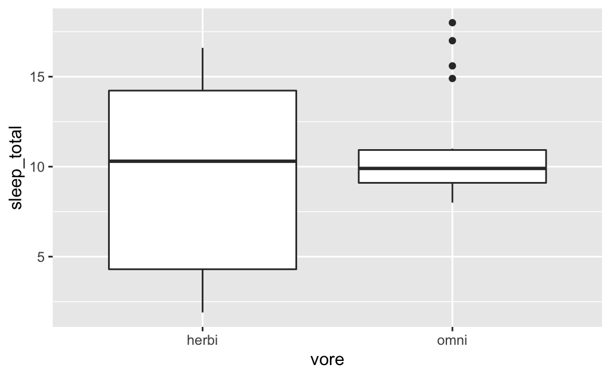

```r
vore_sleep %>%
  ggplot(aes(y = sleep_total, x = vore)) +
  geom_boxplot()
```

Caqlculate null distribution

```r
null_distribution_vore <- vore_sleep %>%
  specify(sleep_total ~ vore) %>%
  hypothesise(null = "independence") %>%
  generate(reps = 1000, type = "permute") %>%
  calculate(stat = "diff in means", order = c("omni", "herbi"))

head(null_distribution_vore)
```

| replicate | stat |
| --- | --- |
| 1 | 1.700000 |
| 2 | 0.781875 |
| 3 | 1.269375 |
| 4 | -1.338750 |
| 5 | -1.720625 |
| 6 | 0.335000 |

Observed statistic

```r
observed_stat_vore <- vore_sleep %>%
  specify(sleep_total ~ vore) %>%
  calculate(stat = "diff in means", order = c("omni", "herbi"))

observed_stat_vore
```

| stat |
| --- |
| 1.415625 |

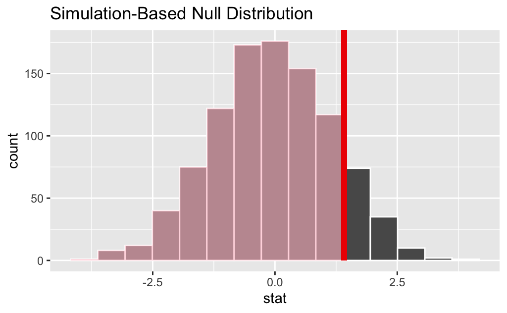

```r
null_distribution_vore %>%
  visualise() +
  shade_p_value(obs_stat = observed_stat_vore, direction = "left")
```

Calculate p value

```r
p_value_vore <- null_distribution_vore %>%
  get_p_value(obs_stat = observed_stat_vore, direction = "left")
p_value_vore
```

| p_value |
| --- |
| 0.883 |

p > 0.05 so null hypothesis cannot be rejected and conclude omnivores do not sleep significantly longer than herbivores on average

# Perform an appropriate statistical test to determine whether the proportion of domesticated animal types in the population of animal types is greater than 5%.

Assuming animal types refers to omniverous and herbivorous categories from previous question

Create is_domesticated variable

```r
domesticated <- vore_sleep %>%
  mutate(is_domesticated = if_else(conservation == "domesticated" & !is.na(conservation), "yes", "no"))
```

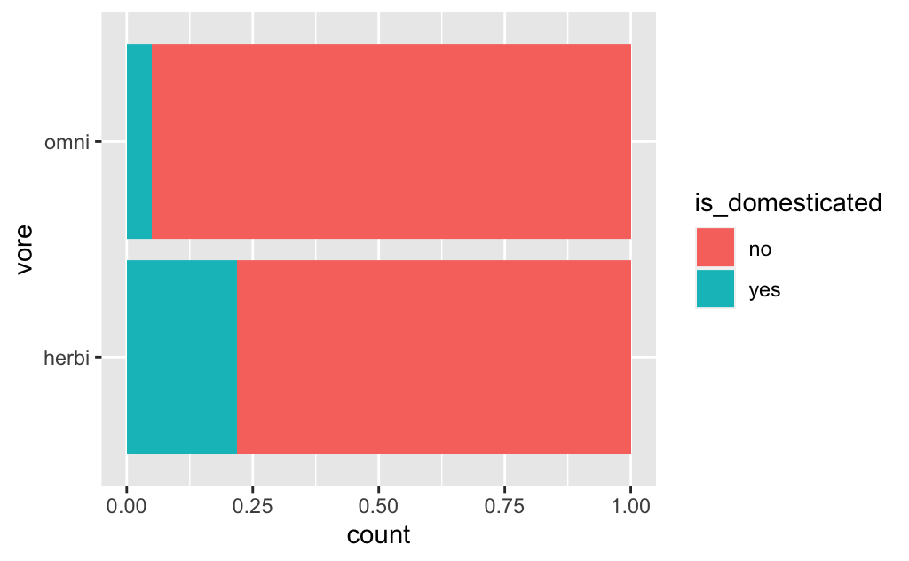

```r
ggplot(domesticated, aes(x = vore, fill = is_domesticated)) +
  geom_bar(position = "fill") +
  coord_flip()
```

```r
observed_stat_dom <- domesticated %>%
  specify(is_domesticated ~ vore, success = "yes") %>%
  calculate(stat = "diff in props", order = c("herbi", "omni"))

observed_stat_dom
```

| stat |
| --- |
| 0.16875 |

```r
null_distribution_dom <- domesticated %>%
  specify(is_domesticated ~ vore, success = "yes") %>%
  hypothesize(null = "independence") %>%
  generate(reps = 1000, type = "permute") %>%
  calculate(stat = "diff in props", order = c("herbi", "omni"))

head(null_distribution_dom)
```

| replicate | stat |
| --- | --- |
| 1 | 0.00625 |
| 2 | 0.00625 |
| 3 | -0.15625 |
| 4 | 0.00625 |
| 5 | 0.00625 |
| 6 | -0.23750 |

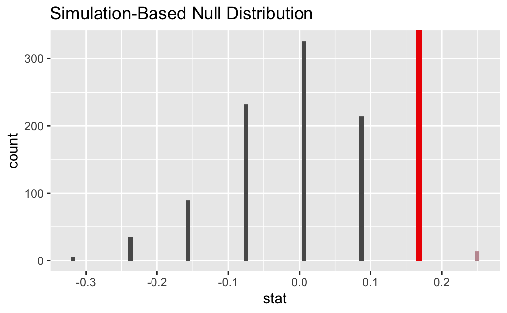

```r
null_distribution_dom %>%
  visualise() +
  shade_p_value(obs_stat = observed_stat_dom, direction = "right")
```

```r
p_value_dom <- null_distribution_dom %>%
  get_p_value(obs_stat = observed_stat_dom, direction = "right")

p_value_dom
```

| p_value |
| --- |
| 0.097 |

Just realised I’ve probably just worked out the wrong thing the wrong way,hmmm

#1.2 Hypothesis testing - interpretation #1.2.1 Defining the Hypothesis

1 H0: πknow of coffee shop >=0.40 Ha: πknow of coffee shop≠0.40

method = simulate

2 H0: πbanner_top−πbanner_right=0 Ha: πbanner_top−πbanner_right>0

method = permutation

3 H0: μpart_width = 145mm Ha: μpart_width ≠ 145mm

method = bootstrapping

#1.2.2 Interpreting the results